# these nesrine

- Montrer tout le code
- Cacher tout le code
- Voir les sources

Date de publication

21 juillet 2026

**AvertissementRapport statistique en cours de rédaction**

# 1 Structure du projet

- **config/helpers partagés, chargés par `_setup.R`**
  - check_helpers.R
  - export_office.R
  - fig_helpers.R
  - misc_helpers.R
  - model_helpers.R
  - tbl_helpers.R
- output/figures et tableaux exportés (png, svg, html)
- rv/bibliothèque et scripts d’amorçage rv
- **scripts/un script par sortie, exécutés par `auto_exec()`**
  - _checks.R
  - _fig_cuminc_strata.R
  - _fig_cuminc_total.R
  - _fig_suivi.R
  - _fig_ttt.R
  - _setup.Rrecodage des données et chargement de `config/`
  - _tbl_model_coxph_lm.R
  - _tbl_model_coxph_td.R
  - _tbl_model_crr.R
  - fig_flowchart.R
  - fig_follow.R
  - fig_surv_strata.R
  - fig_surv_total.R
  - tbl_baseline.R
  - tbl_event.R
  - tbl_fit.R
  - tbl_model_coxph.R
  - tbl_model_glm_bin.R
  - tbl_model_glm_plr.R
  - tbl_model_glm_pois.R
  - tbl_outcome.R
  - tbl_tox_adj.R
  - tbl_tox_induc.R
  - tbl_ttt_adj.R
  - tbl_ttt_induc.R
  - tbl_tumor.R
- .gitignore
- .Renviron
- .Rprofileamorçage de rv à l’ouverture de la session
- air.tomlconfiguration du formateur R
- backup.Rsauvegarde locale des feuilles Google Sheets
- filetree.yml
- index.qmdrapport statistique, source du rendu HTML
- NOTES.md
- rproject.tomldépendances du projet
- rv.lockversions verrouillées des dépendances
- tables.qmdexport des tableaux vers Word
- TODO.md

# 2 Résultats

```r
source("rv/scripts/rvr.R")
source("rv/scripts/activate.R")
# .rv$sync()
# .rv$summary()

options(
  repos = c(CRAN = "https://packagemanager.posit.co/cran/latest"),
  gargle_oauth_email = Sys.getenv("GARGLE_OAUTH_EMAIL", unset = NA)
  # openxlsx2.maxWidth = 60,
)

library(conflicted)
library(tidyverse)
library(googlesheets4)
library(rlang)
library(broom)
library(labelled)
library(gtsummary)
library(ggsurvfit)
library(survival)
library(tidycmprsk)
library(ggrepel)
library(gt)
library(ggswim)
library(patchwork)
library(Gmisc)
library(grid)
library(officer)
library(rvg)
library(hebstr)

print(conflict_scout())

conflicts_prefer(dplyr::filter, Gmisc::coords, .quiet = TRUE)

auto_exec("config", quiet = TRUE)

lang_fr()

set_opts(
  acro = acro(
    DM ~ "données manquantes par groupe"
  ),
  font = "luciole"
)

opts <- get_opts()

update_geom_defaults("text", list(family = opts$font$alpha))

### GS IMPORT ------------------------------------------------------------------

sheets <- map(
  set_names(1:3, "variables", "inclusions", "exclusions"),
  ~ read_sheet(
    ss = "https://docs.google.com/spreadsheets/d/11yV-hnL3OBmuUa5EOKfJylzl1yeg4WrleTKy8CKc2yI/edit?gid=102661300#gid=102661300",
    sheet = .x,
    col_types = "c"
  )
)

dict <- extract_from_dict(
  data = sheets$variables,
  var_name = var_name,
  var_label = var_label,
  type = type,
  level = level
)

easy_label <- \(data, variable = list(), value = list()) {
  data |>
    modify_if(is.logical, as.numeric) |>
    set_variable_labels(!!!dict$var, !!!variable, .strict = FALSE) |>
    set_value_labels(!!!dict$val, !!!value, .strict = FALSE) |>
    mutate(across(any_of(dict$type$int) | where(is.labelled), labelled::to_factor))
}

df_init <- sheets$inclusions |>
  rownames_to_column() |>
  mutate(
    rowname = as.numeric(rowname) + 1,
    across(any_of(c(dict$type$dbl, dict$type$int)), as.numeric),
    across(all_of(dict$type$date), dmy)
  )
```

```r
### DF -------------------------------------------------------------------------

df_recode <- df_init |>
  mutate(
    age = trunc(as.numeric(date_diag - date_birth) / 365.25 * 10) / 10,
    time_diag_chir = time_length(interval(date_diag, date_chir), "months"),
    across(starts_with("tm_stade"), factor),
    tm_stade_t = fct_collapse(tm_stade_t, "T1-T2" = 1:2, "T3-T4" = 3:4),
    tm_stade_n = tm_stade_n |> fct_relabel(~ str_glue("N{.x}")),
    tm_stade_m = tm_stade_m |> fct_relabel(~ str_glue("M{.x}")),
    chir_complic_class_maj = chir_complic_class >= 3,
    # chir_complic_class = fct_collapse(factor(chir_complic_class), "III-IV-V" = 3:5),
    induc_nb = coalesce(induc_nb, 0),
    adj_nb = coalesce(adj_nb, 0),
    n_cures = induc_nb + adj_nb,
    n_cures_outcome = n_cures < 12,
    n_cures_outcome_sub = n_cures_outcome |
      induc_adapt_pct %in% 2 |
      adj_adapt_pct %in% 2,
    total_ei = coalesce(induc_ei, adj_ei),
    n_recidive_site_meta = rowSums(across(starts_with("recidive_site_meta"))) |>
      na_if(0),
    n_recidive_site_meta = if_else(n_recidive_site_meta == 1, 1, 2),
    os_date = date_death,
    os_event = complete.cases(os_date),
    os_tte = time_length(
      x = interval(date_diag, coalesce(os_date, date_lastnews)),
      unit = "months"
    ),
    pfs_date = pmin(date_recidive, date_death, na.rm = TRUE),
    pfs_event = complete.cases(pfs_date),
    pfs_tte = time_length(
      x = interval(date_chir, coalesce(pfs_date, date_lastnews)),
      unit = "months"
    ),
    pfs_cause = case_when(
      !is.na(date_recidive) &
        (is.na(date_death) | date_recidive <= date_death) ~ 1,
      !is.na(date_death) ~ 2,
      .default = 0
    )
  ) |>
  easy_cut(
    var = age,
    values = c(60, 70),
    labels = c("<60", "60-69", "≥70")
  ) |>
  easy_cut(
    var = age,
    incr = TRUE,
    from = 40,
    to = 85,
    by = 5
  ) |>
  easy_label(
    variable = list(
      age = "Âge au diagnostic, années",
      age_cat = "Âge au diagnostic, années",
      age_incr = "Âge au diagnostic, années",
      time_diag_chir = "Délai entre diagnostic et chirurgie, mois",
      chir_complic_class_maj = "Complication post-opératoire majeure",
      n_cures = "Nombre total de cures",
      n_cures_outcome = "Nombre total de cures < 12",
      n_cures_outcome_sub = "Nombre total de cures < 12 : ou dose relative moyenne < 80%",
      total_ei = "Toxicité de grade III-IV",
      n_recidive_site_meta = "Nombre de sites métastatiques",
      os_event = "Décès toutes causes",
      os_tte = "Délai entre le diagnostic et le décès toutes causes, mois",
      pfs_event = "Récidive ou décès toutes causes",
      pfs_tte = "Délai entre la chirurgie et la récidive ou le décès toutes causes, mois",
      pfs_cause = "Premier évènement"
    ),
    value = list(
      n_recidive_site_meta = c("1" = 1, ">=2" = 2),
      pfs_cause = c("Censure" = 0, "Récidive" = 1, "Décès sans récidive" = 2)
    )
  ) |>
  discard(~ is.null(var_label(.x)))

df <- df_recode |>
  rownames_to_column() |>
  mutate(rowname = as.numeric(rowname) + 1)

.induc <- lst(
  label = var_label(df$groupe),
  level = levels(df$groupe)[2],
  n = sum(df$groupe == level, na.rm = TRUE),
  df = df |>
    filter(groupe == level) |>
    mutate(groupe = fct_drop(groupe))
)

.tox_vars <- map(
  set_names(c("induc", "adj")),
  ~ names(df) |>
    str_subset(str_glue("{.x}_ei_")) |>
    set_names() |>
    imap_dbl(~ sum(as.numeric(df[[.]]), na.rm = TRUE)) |>
    sort(decreasing = TRUE) |>
    names()
)

.check_df <- lst(
  data_recode = df |> select(-rowname),
  names = names(data_recode),
  data_init = df_init |> select(any_of(names)) |> easy_label(),
  vars = easy_view(data_recode)$output,
  distrib_recode = check_distrib(data_recode),
  distrib_init = check_distrib(data_init),
)

### FIT ------------------------------------------------------------------------

.followup <- build_model(
  data = df,
  tte = os_tte,
  event = 1 - os_event,
  strata = groupe,
  estimate_label = "récidive ou décès",
  tbl_label = "Probabilité d'être encore suivi",
  type = "surv"
)

.surv <- lst(
  os = build_model(
    data = df,
    tte = os_tte,
    event = os_event,
    strata = groupe,
    estimate_label = "le décès toutes causes",
    tbl_label = "Probabilité de survie globale",
    type = "surv"
  ),
  pfs = build_model(
    data = df,
    tte = pfs_tte,
    event = pfs_event,
    strata = groupe,
    estimate_label = "la récidive ou le décès toutes causes",
    tbl_label = "Probabilité de survie sans récidive",
    type = "surv"
  )
) |>
  list_transpose()

.surv_labs <- list(
  os = list(
    x = "Durée depuis le diagnostic (mois)",
    y = "Probabilité de survie globale (%)"
  ),
  pfs = list(
    x = "Durée depuis la chirurgie (mois)",
    y = "Probabilité de survie sans récidive (%)"
  )
)

.cmp <- build_model(
  data = df,
  tte = pfs_tte,
  event = pfs_cause,
  strata = groupe,
  estimate_label = "la récidive",
  tbl_label = "Probabilité de survie sans récidive (%)",
  type = "cmp"
)

.fig_palette <- c(opts$color$base, opts$color$cold[2])

### MODEL ----------------------------------------------------------------------

.model <- lst()

.model$default <- lst(
  data = df |> mutate(ps_diag = ps_diag |> fct_collapse("1-2" = c(1, 2))),
  vars = set_model_vars(
    y = "n_cures_outcome",
    x_uv = c(
      "groupe",
      "centre",
      "age_incr",
      "ps_diag",
      "chir_resec"
    ),
    x_mv_exclude = "chir_resec"
  ),
  args = lst(
    pvalue_fun = opts$pvalue$format,
    exponentiate = TRUE
  )
)

### AUTO EXEC ------------------------------------------------------------------

# auto_exec()
```

## 2.1 Variables

**Variables**

Vue d’ensemble des variables utilisées

| n | variable | label | type | n_miss | p_miss | levels |
| --- | --- | --- | --- | --- | --- | --- |
| 1 | centre | Centre | fct | NA | NA | ['CHU Nantes', 'CHD Vendée', 'CHU Angers', 'CHU Lyon'] |
| 2 | groupe | Protocole de chimiothérapie | fct | NA | NA | ['Adjuvant seul', 'Péri-opératoire'] |
| 3 | sexe | Sexe | fct | NA | NA | ['Femme', 'Homme'] |
| 4 | date_birth | Date de naissance | date | NA | NA | NA |
| 5 | date_diag | Date du diagnostic | date | NA | NA | NA |
| 6 | date_chir | Date de chirurgie | date | NA | NA | NA |
| 7 | dl_diag | Douleur au diagnostic | fct | 5 | 4,9% | ['Non', 'Oui'] |
| 8 | tm_histo | Type histologique | fct | NA | NA | ['Adénocarcinome', 'Autre'] |
| 9 | tm_loc | Localisation tumorale | fct | NA | NA | ['Tête', 'Corps', 'Queue'] |
| 10 | tm_stade_t | Stade T | fct | 3 | 2,9% | ['T1-T2', 'T3-T4'] |

[output cut: 78 more lines]

**Effectifs (init)**

Effectifs bruts avant recodage

| **Caractéristique** | **DM** | **N = 103** |
| --- | --- | --- |
| Centre, n (%) |  |  |
| CHU Nantes |  | 25 (24,3) |
| CHD Vendée |  | 25 (24,3) |
| CHU Angers |  | 36 (35,0) |
| CHU Lyon |  | 17 (16,5) |
| Protocole de chimiothérapie, n (%) |  |  |
| Adjuvant seul |  | 53 (51,5) |
| Péri-opératoire |  | 50 (48,5) |
| Sexe, n (%) |  |  |
| Femme |  | 47 (45,6) |
| Homme |  | 56 (54,4) |
| Douleur au diagnostic, n (%) | 5 |  |
| Non |  | 58 (59,2) |
| Oui |  | 40 (40,8) |
| Type histologique, n (%) |  |  |
| Adénocarcinome |  | 103 (100,0) |
| Autre |  | 0 |
| Localisation tumorale, n (%) |  |  |
| Tête |  | 79 (76,7) |
| Corps |  | 13 (12,6) |
| Queue |  | 11 (10,7) |
| Stade T, n (%) | 3 |  |
| 1 |  | 23 (23,0) |
| 2 |  | 62 (62,0) |
| 3 |  | 13 (13,0) |
| 4 |  | 2 (2,0) |
| Stade N, n (%) | 3 |  |
| 0 |  | 29 (29,0) |
| 1 |  | 49 (49,0) |
| 2 |  | 22 (22,0) |

[output cut: 220 more lines]

IQR : intervalle interquartile ; DM : données manquantes par groupe.

**Effectifs (recode)**

Effectifs après éventuel recodage

| **Caractéristique** | **DM** | **N = 103** |
| --- | --- | --- |
| Centre, n (%) |  |  |
| CHU Nantes |  | 25 (24,3) |
| CHD Vendée |  | 25 (24,3) |
| CHU Angers |  | 36 (35,0) |
| CHU Lyon |  | 17 (16,5) |
| Protocole de chimiothérapie, n (%) |  |  |
| Adjuvant seul |  | 53 (51,5) |
| Péri-opératoire |  | 50 (48,5) |
| Sexe, n (%) |  |  |
| Femme |  | 47 (45,6) |
| Homme |  | 56 (54,4) |
| Douleur au diagnostic, n (%) | 5 |  |
| Non |  | 58 (59,2) |
| Oui |  | 40 (40,8) |
| Type histologique, n (%) |  |  |
| Adénocarcinome |  | 103 (100,0) |
| Autre |  | 0 |
| Localisation tumorale, n (%) |  |  |
| Tête |  | 79 (76,7) |
| Corps |  | 13 (12,6) |
| Queue |  | 11 (10,7) |
| Stade T, n (%) | 3 |  |
| T1-T2 |  | 85 (85,0) |
| T3-T4 |  | 15 (15,0) |
| Stade N, n (%) | 3 |  |
| N0 |  | 29 (29,0) |
| N1 |  | 49 (49,0) |
| N2 |  | 22 (22,0) |
| Stade M, n (%) | 1 |  |
| M0 |  | 102 (100,0) |

[output cut: 250 more lines]

IQR : intervalle interquartile ; DM : données manquantes par groupe.

## 2.2 Flowchart

```r
### DATA -----------------------------------------------------------------------

df_flow <- sheets$exclusions |>
  select(centre, motif_exclusion) |>
  bind_rows(sheets$inclusions[, "centre"]) |>
  mutate(
    across(c(centre, motif_exclusion), as.numeric),
    motif_exclusion = replace_na(motif_exclusion, 0)
  ) |>
  set_value_labels(!!!dict$val, .strict = FALSE) |>
  modify_if(is.labelled, labelled::to_factor)

label_centre <- get_label(df_recode, centre)

label_exclus <- df_flow |>
  filter(motif_exclusion != 0) |>
  get_label(motif_exclusion)

n_groupe <- fct_count(df_recode$groupe)

n <- lst(
  eligible = nrow(df_flow),
  exclus = sum(df_flow$motif_exclusion != 0),
  inclus = eligible - exclus,
  chimio_adj = n_groupe$n[1],
  chimio_periop = n_groupe$n[2]
)

### GROBS ----------------------------------------------------------------------

col_blue <- "#08F"
col_dark <- "#111"
col_grey <- "grey95"
base_fontsize <- 11
base_textcolor <- "#333"

options(
  connectGrob = gpar(col = "#09F", lwd = 1.5),
  connectGrobArrow = arrow(length = unit(0, "mm"))
)

txt_gp <- \(fontsize = base_fontsize, col = base_textcolor) {
  gpar(
    fontsize = fontsize,
    col = col,
    fontfamily = opts$font$alpha
  )
}

flow_box <- \(
  label,
  x,
  y,
  just = "center",
  col = col_blue,
  fill = "#FFF",
  lwd = 1.5,
  txt = txt_gp()
) {
  boxGrob(
    label = label,
    x = x,
    y = y,
    just = just,
    box_gp = gpar(fill = fill, col = col, lwd = lwd),
    txt_gp = txt
  )
}

eligible_box <- flow_box(
  str_glue(
    "Patients éligibles (N = {n$eligible})
    - Hommes et femmes >= 18 ans
    - Opérés d'un cancer du pancréas
    - Entre 01/2022 et 12/2025"
  ),
  x = 0.4,
  y = 0.9,
  just = "left",
  col = col_dark
)

exclus_box <- flow_box(
  str_glue("Exclus (n = {n$exclus})\n{label_exclus}"),
  x = 0.75,
  y = 0.775,
  just = "left",
  col = col_grey,
  fill = col_grey,
  lwd = 1.2,
  txt = txt_gp(base_fontsize - 1.5, col = "#555")
)

coords_exclus_box <- coords(exclus_box)
anchor_exclus_box <- boxGrob(
  label = "",
  x = coords_exclus_box$left,
  y = coords_exclus_box$y * 1,
  width = unit(0, "mm"),
  height = unit(0, "mm"),
  box_gp = gpar(col = NA, fill = NA)
)
anchor_exclus_connect <- connectGrob(
  eligible_box,
  anchor_exclus_box,
  type = "L",
  lty_gp = gpar(col = "grey90", lwd = 2.5)
)

inclus_box <- flow_box(
  str_glue("Inclus (n = {n$inclus})\n{label_centre}"),
  x = 0.4,
  y = 0.6,
  just = "left"
)
inclus_connect <- connectGrob(
  eligible_box,
  inclus_box,
  type = "vertical",
  lty_gp = gpar(col = base_textcolor, lwd = 1.5)
)

adjuvant_box <- flow_box(
  label = str_glue("Chimiothérapie adjuvante seule\n(n = {n$chimio_adj})"),
  x = 0.225,
  y = 0.35
)
adjuvant_connect <- connectGrob(inclus_box, adjuvant_box, type = "N")

periop_box <- flow_box(
  label = str_glue("Chimiothérapie péri-opératoire\n(n = {n$chimio_periop})"),
  x = 0.575,
  y = 0.35
)
periop_connect <- connectGrob(inclus_box, periop_box, type = "N")

### FIG ------------------------------------------------------------------------

fig_flowchart <- grobTree(
  eligible_box,
  exclus_box,
  inclus_box,
  adjuvant_box,
  periop_box,
  anchor_exclus_connect,
  inclus_connect,
  adjuvant_connect,
  periop_connect
)

easy_out(fig_flowchart, width = 9, height = 8)

# export_office(fig_flowchart, width = 9, height = 8)
```

**Importantexclus : nettoyage/clarification des motifs (ambiguité autre chimio/autre anapat/autre)**

Dans un premier temps, 337 patients ont été retenus pour éligibilité. Parmi ces patients, 234 ont été exclus.

Au total, ont été inclus 103 patients adultes atteints d’un cancer du pancréas opéré entre janvier 2022 et décembre 2025, au CHU de Nantes ou dans un autre centre (4 centres au total).

Figure 1. Flowchart.

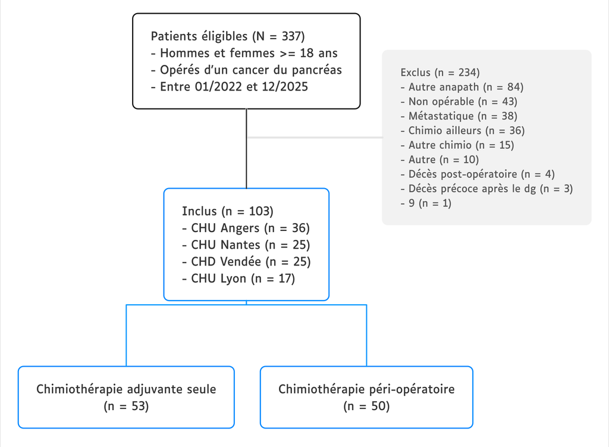

## 2.3 Analyse descriptive

### 2.3.1 Caractéristiques des patients at baseline

```r
tbl_baseline <- df |>
  select(
    groupe,
    centre,
    sexe,
    age,
    age_cat,
    ps_diag,
    dl_diag,
    ca_diag,
    tm_loc,
    starts_with("tm_stade")
  ) |>
  use_vars() |>
  tbl_summary(
    by = groupe,
    statistic = opts$vars$stat,
    value = binary_value(df),
    digits = opts$digits,
    missing = "ifany",
    missing_text = opts$labs$row_missing
  ) |>
  add_stat_label(label = opts$vars$label) |>
  gtsum_format() |>
  tbl_format(width = 750)

easy_out(tbl_baseline)
```

Table 1. Caractéristiques des patients at baseline, globalement et selon le protocole de chimiothérapie.

| **Variable** | **DM** | Total (N=103) | **Protocole de chimiothérapie** Adjuvant seul (n=53, 51,5%) | **Protocole de chimiothérapie** Péri-opératoire (n=50, 48,5%) |
| --- | --- | --- | --- | --- |
| Centre, n (%) |  |  |  |  |
| CHU Nantes |  | 25 (24,3) | 16 (30,2) | 9 (18,0) |
| CHD Vendée |  | 25 (24,3) | 15 (28,3) | 10 (20,0) |
| CHU Angers |  | 36 (35,0) | 12 (22,6) | 24 (48,0) |
| CHU Lyon |  | 17 (16,5) | 10 (18,9) | 7 (14,0) |
| Sexe, n (%) |  |  |  |  |
| Femme |  | 47 (45,6) | 20 (37,7) | 27 (54,0) |
| Homme |  | 56 (54,4) | 33 (62,3) | 23 (46,0) |
| Âge au diagnostic, années, médiane (IQR) |  | 65,3 (57,9—70,8) | 66,1 (59,5—71,9) | 63,5 (55,8—67,9) |
| Âge au diagnostic, années, n (%) |  |  |  |  |
| <60 |  | 33 (32,0) | 15 (28,3) | 18 (36,0) |
| 60-69 |  | 42 (40,8) | 21 (39,6) | 21 (42,0) |
| ≥70 |  | 28 (27,2) | 17 (32,1) | 11 (22,0) |
| PS au diagnostic, n (%) | 9/4 |  |  |  |
| 0 |  | 60 (66,7) | 36 (81,8) | 24 (52,2) |
| 1 |  | 27 (30,0) | 7 (15,9) | 20 (43,5) |
| 2 |  | 3 (3,3) | 1 (2,3) | 2 (4,3) |
| Douleur au diagnostic, n (%) | 2/3 | 40 (40,8) | 19 (37,3) | 21 (44,7) |
| CA 19-9 au diagnostic, UI/L, médiane (IQR) | 23/23 | 82,0 (20,0—147,0) | 79,0 (25,0—110,0) | 90,0 (19,0—331,0) |
| Localisation tumorale, n (%) |  |  |  |  |
| Tête |  | 79 (76,7) | 38 (71,7) | 41 (82,0) |
| Corps |  | 13 (12,6) | 8 (15,1) | 5 (10,0) |
| Queue |  | 11 (10,7) | 7 (13,2) | 4 (8,0) |
| Stade T, n (%) | 2/1 |  |  |  |
| T1-T2 |  | 85 (85,0) | 41 (80,4) | 44 (89,8) |
| T3-T4 |  | 15 (15,0) | 10 (19,6) | 5 (10,2) |
| Stade N, n (%) | 2/1 |  |  |  |
| N0 |  | 29 (29,0) | 13 (25,5) | 16 (32,7) |
| N1 |  | 49 (49,0) | 28 (54,9) | 21 (42,9) |
| N2 |  | 22 (22,0) | 10 (19,6) | 12 (24,5) |
| Stade M, n (%) | 0/1 |  |  |  |
| M0 |  | 102 (100,0) | 53 (100,0) | 49 (100,0) |

IQR : intervalle interquartile ; DM : données manquantes par groupe.

### 2.3.2 Caractéristiques tumorales et prise en charge chirurgicale

```r
.site_meta_vars <- names(df) |>
  str_subset("site_meta_") |>
  set_names() |>
  imap_dbl(~ sum(as.numeric(df[[.]]))) |>
  sort(decreasing = TRUE) |>
  names()

.site_meta_note <- "Parmi les patients ayant récidivé au niveau métastatique ou local + métastatique."

tbl_tumor <- df |>
  select(
    groupe,
    time_diag_chir,
    chir_resec,
    chir_hosp,
    chir_complic_class,
    chir_complic_class_maj,
    chir_marges,
    recidive_type,
    n_recidive_site_meta,
    all_of(.site_meta_vars)
  ) |>
  mutate(chir_marges = fct_drop(chir_marges)) |>
  use_vars() |>
  tbl_summary(
    by = groupe,
    statistic = opts$vars$stat,
    value = binary_value(df),
    digits = opts$digits,
    missing = "ifany",
  ) |>
  add_stat_label(label = opts$vars$label) |>
  gtsum_format() |>
  remove_row_type(variables = "n_recidive_site_meta", type = "missing") |>
  add_label(name = "Site métastatique", levels = .site_meta_vars) |>
  add_note(
    vars = "chir_complic_class",
    note = "Selon la classification de Clavien-Dindo."
  ) |>
  add_note(
    vars = "chir_resec",
    note = "Selon les critères du National Comprehensive Cancer Network (NCCN)."
  ) |>
  add_note(vars = "n_recidive_site_meta", note = .site_meta_note) |>
  add_note(levels = "Site métastatique", note = .site_meta_note) |>
  tbl_format(width = 750)

easy_out(tbl_tumor)
```

Table 2. Caractéristiques tumorales et prise en charge chirurgicale, globalement et selon le protocole de chimiothérapie.

| **Variable** | **DM** | Total (N=103) | **Protocole de chimiothérapie** Adjuvant seul (n=53, 51,5%) | **Protocole de chimiothérapie** Péri-opératoire (n=50, 48,5%) |
| --- | --- | --- | --- | --- |
| Délai entre diagnostic et chirurgie, mois, médiane (IQR) |  | 3,3 (1,5—5,7) | 1,5 (1,1—2,1) | 5,2 (4,2—7,1) |
| Résécabilité, n (%)* | 3/2 |  |  |  |
| Résécable d'emblée |  | 62 (63,3) | 50 (100,0) | 12 (25,0) |
| Borderline |  | 19 (19,4) | 0 | 19 (39,6) |
| Localement avancé |  | 17 (17,3) | 0 | 17 (35,4) |
| Durée d'hospitalisation, jours, médiane (IQR) | 3/2 | 16,0 (12,0—23,0) | 16,5 (12,0—21,0) | 15,0 (12,0—23,0) |
| Complication post-opératoire, n (%)† | 2/3 |  |  |  |
| 0 |  | 60 (61,2) | 29 (56,9) | 31 (66,0) |
| I |  | 12 (12,2) | 6 (11,8) | 6 (12,8) |
| II |  | 12 (12,2) | 8 (15,7) | 4 (8,5) |
| III |  | 11 (11,2) | 7 (13,7) | 4 (8,5) |
| IV |  | 2 (2,0) | 1 (2,0) | 1 (2,1) |
| V |  | 1 (1,0) | 0 | 1 (2,1) |
| Complication post-opératoire majeure, n (%) | 2/3 | 14 (14,3) | 8 (15,7) | 6 (12,8) |
| Résection chirurgicale, n (%) | 2/6 |  |  |  |
| R0 |  | 68 (71,6) | 36 (70,6) | 32 (72,7) |
| R1 |  | 27 (28,4) | 15 (29,4) | 12 (27,3) |
| Type de récidive, n (%) |  |  |  |  |
| Aucune |  | 46 (44,7) | 27 (50,9) | 19 (38,0) |
| Locale |  | 18 (17,5) | 6 (11,3) | 12 (24,0) |
| Métastatique |  | 28 (27,2) | 13 (24,5) | 15 (30,0) |
| Locale et métastatique |  | 11 (10,7) | 7 (13,2) | 4 (8,0) |
| Nombre de sites métastatiques, n (%)‡ |  |  |  |  |
| 1 |  | 28 (68,3) | 13 (61,9) | 15 (75,0) |
| >=2 |  | 13 (31,7) | 8 (38,1) | 5 (25,0) |
| Site métastatique‡ |  |  |  |  |
| Récidive hépatique, n (%) |  | 23 (22,3) | 14 (26,4) | 9 (18,0) |
| Récidive péritonéale, n (%) |  | 13 (12,6) | 7 (13,2) | 6 (12,0) |
| Récidive ganglionnaire, n (%) |  | 10 (9,7) | 7 (13,2) | 3 (6,0) |
| Récidive pulmonaire, n (%) |  | 10 (9,7) | 3 (5,7) | 7 (14,0) |
| Récidive cérébrale, n (%) |  | 1 (1,0) | 0 | 1 (2,0) |
| Récidive autre, n (%) |  | 1 (1,0) | 1 (1,9) | 0 |

IQR : intervalle interquartile ; DM : données manquantes par groupe.  
* Selon les critères du National Comprehensive Cancer Network (NCCN).  
† Selon la classification de Clavien-Dindo.  
‡ Parmi les patients ayant récidivé au niveau métastatique ou local + métastatique.

### 2.3.3 Critère de jugement principal

```r
tbl_outcome <- df |>
  select(
    groupe,
    induc_chimio,
    induc_nb,
    adj_chimio,
    adj_nb,
    n_cures_outcome,
    n_cures_outcome_sub,
  ) |>
  strip_label(str_glue("^(Induction|Adjuvant)\\s*:\\s*")) |>
  strip_label(
    str_glue("^{var_label(df$n_cures_outcome)}\\s*:\\s*"),
    to_upper = FALSE
  ) |>
  use_vars() |>
  tbl_summary(
    by = groupe,
    statistic = opts$vars$stat,
    value = binary_value(df),
    digits = opts$digits,
    missing = "ifany",
    missing_text = opts$labs$row_missing
  ) |>
  add_stat_label(label = opts$vars$label) |>
  gtsum_format() |>
  modify_indent(
    columns = label,
    rows = variable %in%
      c("induc_nb", "adj_nb", "n_cures_outcome_sub") &
      row_type %in% 'label'
  ) |>
  modify_table_body(
    ~ .x |>
      mutate(across(
        c(stat_0, stat_1),
        \(x) if_else(variable %in% c("induc_chimio", "induc_nb"), "–", x)
      ))
  ) |>
  add_note(
    vars = c("induc_chimio", "adj_chimio"),
    note = "Nombre de patients ayant reçu au moins une cure.",
  ) |>
  tbl_format(width = 650)

easy_out(tbl_outcome)
```

Outcome : schéma incomplet (nombre total de cures reçues < 12)

Table 3. Nombre de cures reçues, globalement et selon le protocole de chimiothérapie.

| **Variable** | Total (N=103) | **Protocole de chimiothérapie** Adjuvant seul (n=53, 51,5%) | **Protocole de chimiothérapie** Péri-opératoire (n=50, 48,5%) |
| --- | --- | --- | --- |
| Chimiothérapie d'induction, n (%)* | – | – | 50 (100,0) |
| Nombre de cures, médiane (IQR) | – | – | 6,0 (5,0—9,0) |
| Chimiothérapie adjuvante, n (%)* | 94 (91,3) | 50 (94,3) | 44 (88,0) |
| Nombre de cures, médiane (IQR) | 6,0 (5,0—12,0) | 12,0 (10,0—12,0) | 6,0 (4,0—6,0) |
| Nombre total de cures < 12, n (%) | 38 (36,9) | 22 (41,5) | 16 (32,0) |
| ou dose relative moyenne < 80%, n (%) | 97 (94,2) | 49 (92,5) | 48 (96,0) |

IQR : intervalle interquartile.  
* Nombre de patients ayant reçu au moins une cure.

### 2.3.4 Caractéristiques du traitement

Doses reçues et adaptations de doses, par phase de chimiothérapie.

#### 2.3.4.1 Phase d’induction

```r
tbl_ttt_induc <- .induc$df |>
  filter(induc_nb > 0) |>
  select(
    groupe,
    matches("induc_dose"),
    induc_adapt,
    induc_adapt_pct,
    starts_with("induc_adapt_c"),
  ) |>
  strip_label("^(Induction|Adjuvant)\\s*: (dose)?\\s*") |>
  use_vars() |>
  tbl_summary(
    by = groupe,
    statistic = opts$vars$stat,
    type = matches("induc_dose") ~ "continuous",
    value = binary_value(df),
    digits = opts$digits,
    missing = "ifany",
    missing_text = opts$labs$row_missing
  ) |>
  add_stat_label(label = opts$vars$label) |>
  gtsum_format() |>
  add_label(
    name = "Dernière dose reçue",
    levels = c("induc_dose_5fu", "induc_dose_irino", "induc_dose_oxali")
  ) |>
  modify_column_hide(columns = stat_0) |>
  modify_header(all_stat_cols(stat_0 = FALSE) ~ "**{level}<br>(n={n})**") |>
  tbl_format(width = 500)

easy_out(tbl_ttt_induc)
```

Table 4. Doses reçues et adaptations de doses à la phase d’induction, selon le protocole de chimiothérapie.

| **Variable** | **DM** | **Protocole de chimiothérapie** Péri-opératoire (n=50) |
| --- | --- | --- |
| Dernière dose reçue |  |  |
| 5-FU, %, médiane (IQR) |  | 100,0 (80,0—100,0) |
| Irinotécan, %, médiane (IQR) |  | 70,0 (60,0—90,0) |
| Oxaliplatine, %, médiane (IQR) |  | 80,0 (50,0—100,0) |
| Adaptation de doses, n (%) |  | 43 (86,0) |
| Pourcentage d'adaptation, n (%) |  |  |
| Pas d'adaptation |  | 6 (12,0) |
| <=20% |  | 6 (12,0) |
| >20% |  | 38 (76,0) |
| Adaptation de dose à C4, n (%) | 1 |  |
| Non |  | 10 (20,4) |
| <=20% |  | 14 (28,6) |
| >20% |  | 25 (51,0) |
| Adaptation de dose à C8, n (%) | 33 |  |
| Non |  | 1 (5,9) |
| <=20% |  | 7 (41,2) |
| >20% |  | 9 (52,9) |
| Adaptation de dose à C12, n (%) | 46 |  |
| Non |  | 0 |
| <=20% |  | 2 (50,0) |
| >20% |  | 2 (50,0) |

IQR : intervalle interquartile ; DM : données manquantes par groupe.

#### 2.3.4.2 Phase adjuvante

```r
tbl_ttt_adj <- df |>
  filter(adj_nb > 0) |>
  select(
    groupe,
    matches("adj_dose"),
    adj_adapt,
    adj_adapt_pct,
    starts_with("adj_adapt_c"),
  ) |>
  strip_label("^(Induction|Adjuvant)\\s*: (dose)?\\s*") |>
  use_vars() |>
  tbl_summary(
    by = groupe,
    statistic = opts$vars$stat,
    type = matches("adj_dose") ~ "continuous",
    value = binary_value(df),
    digits = opts$digits,
    missing = "ifany"
  ) |>
  add_stat_label(label = opts$vars$label) |>
  gtsum_format() |>
  add_label(
    name = "Dernière dose reçue",
    levels = c("adj_dose_5fu", "adj_dose_irino", "adj_dose_oxali")
  ) |>
  tbl_format()

easy_out(tbl_ttt_adj)

# pct : adaptation max parmi les 3 mol (dernière cure)
```

Table 5. Doses reçues et adaptations de doses à la phase adjuvante, globalement et selon le protocole de chimiothérapie.

| **Variable** | **DM** | Total (N=94) | **Protocole de chimiothérapie** Adjuvant seul (n=50, 53,2%) | **Protocole de chimiothérapie** Péri-opératoire (n=44, 46,8%) |
| --- | --- | --- | --- | --- |
| Dernière dose reçue |  |  |  |  |
| 5-FU, %, médiane (IQR) | 0/2 | 80,0 (75,0—100,0) | 80,0 (75,0—100,0) | 80,0 (75,0—100,0) |
| Irinotécan, %, médiane (IQR) | 0/2 | 70,0 (50,0—80,0) | 70,0 (50,0—80,0) | 70,0 (50,0—75,0) |
| Oxaliplatine, %, médiane (IQR) | 0/2 | 25,0 (0,0—70,0) | 0,0 (0,0—75,0) | 50,0 (0,0—70,0) |
| Adaptation de doses, n (%) | 0/2 | 88 (95,7) | 47 (94,0) | 41 (97,6) |
| Pourcentage d'adaptation, n (%) | 0/2 |  |  |  |
| Pas d'adaptation |  | 4 (4,3) | 3 (6,0) | 1 (2,4) |
| <=20% |  | 8 (8,7) | 6 (12,0) | 2 (4,8) |
| >20% |  | 80 (87,0) | 41 (82,0) | 39 (92,9) |
| Adaptation de dose à C4, n (%) | 3/8 |  |  |  |
| Non |  | 4 (4,8) | 4 (8,5) | 0 |
| <=20% |  | 33 (39,8) | 22 (46,8) | 11 (30,6) |
| >20% |  | 46 (55,4) | 21 (44,7) | 25 (69,4) |
| Adaptation de dose à C8, n (%) | 9/39 |  |  |  |
| Non |  | 2 (4,3) | 2 (4,9) | 0 |
| <=20% |  | 6 (13,0) | 5 (12,2) | 1 (20,0) |
| >20% |  | 38 (82,6) | 34 (82,9) | 4 (80,0) |
| Adaptation de dose à C12, n (%) | 19/44 |  |  |  |
| Non |  | 1 (3,2) | 1 (3,2) | 0 |
| <=20% |  | 6 (19,4) | 6 (19,4) | 0 |
| >20% |  | 24 (77,4) | 24 (77,4) | 0 |

IQR : intervalle interquartile ; DM : données manquantes par groupe.

### 2.3.5 Toxicité chimio-induite

Toxicité chimio-induite de grade III-IV, par phase de chimiothérapie.

#### 2.3.5.1 Phase d’induction

```r
.tox_induc <- lst(
  data = .induc$df |> filter(induc_nb > 0),
  level = binary_value(data)$induc_ei,
  n = nrow(data),
  n_ei = sum(data$induc_ei == level, na.rm = TRUE),
  pct = style_percent(
    n_ei / sum(!is.na(data$induc_ei)),
    symbol = TRUE,
    digits = 1
  )
)

tbl_tox_induc <- .tox_induc$data |>
  select(
    groupe,
    induc_ei,
    all_of(.tox_vars$induc)
  ) |>
  strip_label(str_glue("^Induction\\s*:\\s*|(\\s*grade\\s*3-4)$")) |>
  use_vars() |>
  tbl_summary(
    by = groupe,
    statistic = opts$vars$stat,
    value = binary_value(df),
    digits = opts$digits,
    missing = "ifany",
    missing_text = opts$labs$row_missing
  ) |>
  add_stat_label(label = opts$vars$label) |>
  gtsum_format() |>
  modify_indent(
    columns = label,
    rows = variable %in% .tox_vars$induc & row_type %in% "label"
  ) |>
  modify_column_hide(columns = stat_0) |>
  modify_header(all_stat_cols(stat_0 = FALSE) ~ "**{level}<br>(n={n})**") |>
  add_note(
    vars = "induc_ei",
    note = "Selon la Common Terminology Criteria for Adverse Events (CTCAE).",
  ) |>
  tbl_format(width = 450)

easy_out(tbl_tox_induc)
```

Au total, sur l’ensemble des 50 patients ayant reçu une chimiothérapie d’induction, 10 (20,0%) ont présenté au moins un effet indésirable de grade III-IV.

Table 6. Toxicité chimio-induite de grade III-IV à la phase d’induction, selon le protocole de chimiothérapie.

| **Variable** | **Protocole de chimiothérapie** Péri-opératoire (n=50) |
| --- | --- |
| Toxicité de grade III-IV, n (%)* | 10 (20,0) |
| Vomissement, n (%) | 5 (10,0) |
| Neurotoxicité, n (%) | 4 (8,0) |
| Asthénie, n (%) | 2 (4,0) |
| Diarrhée, n (%) | 1 (2,0) |
| Neutropénie, n (%) | 1 (2,0) |
| Cytolyse/cholestase, n (%) | 1 (2,0) |

* Selon la Common Terminology Criteria for Adverse Events (CTCAE).

#### 2.3.5.2 Phase adjuvante

```r
.tox_adj <- lst(
  data = df |> filter(adj_nb > 0),
  level = binary_value(data)$adj_ei,
  n = nrow(data),
  n_ei = sum(data$adj_ei == level, na.rm = TRUE),
  pct = style_percent(
    n_ei / sum(!is.na(data$adj_ei)),
    symbol = TRUE,
    digits = 1
  )
)

tbl_tox_adj <- .tox_adj$data |>
  select(
    groupe,
    adj_ei,
    all_of(.tox_vars$adj)
  ) |>
  strip_label(str_glue("^(Induction|Adjuvant)\\s*:\\s*|(\\s*grade\\s*3-4)$")) |>
  use_vars() |>
  tbl_summary(
    by = groupe,
    statistic = opts$vars$stat,
    value = binary_value(df),
    digits = opts$digits,
    missing = "ifany",
    missing_text = opts$labs$row_missing
  ) |>
  add_stat_label(label = opts$vars$label) |>
  gtsum_format() |>
  modify_indent(
    columns = label,
    rows = variable %in% .tox_vars$adj & row_type %in% "label"
  ) |>
  add_note(
    vars = "adj_ei",
    note = "Selon la Common Terminology Criteria for Adverse Events (CTCAE).",
  ) |>
  tbl_format(width = 600)

easy_out(tbl_tox_adj)
```

Au total, sur l’ensemble des 94 patients ayant reçu une chimiothérapie adjuvante, 23 (25,0%) ont présenté au moins un effet indésirable de grade III-IV.

Table 7. Toxicité chimio-induite de grade III-IV à la phase adjuvante, globalement et selon le protocole de chimiothérapie.

| **Variable** | **DM** | Total (N=94) | **Protocole de chimiothérapie** Adjuvant seul (n=50, 53,2%) | **Protocole de chimiothérapie** Péri-opératoire (n=44, 46,8%) |
| --- | --- | --- | --- | --- |
| Toxicité de grade III-IV, n (%)* | 0/2 | 23 (25,0) | 20 (40,0) | 3 (7,1) |
| Diarrhée, n (%) | 0/2 | 9 (9,8) | 9 (18,0) | 0 |
| Neurotoxicité, n (%) | 0/2 | 9 (9,8) | 6 (12,0) | 3 (7,1) |
| Nausées/vomissement, n (%) | 0/2 | 8 (8,7) | 8 (16,0) | 0 |
| Asthénie, n (%) | 0/2 | 4 (4,3) | 4 (8,0) | 0 |
| Neutropénie, n (%) | 0/2 | 4 (4,3) | 4 (8,0) | 0 |
| Cytolyse/cholestase, n (%) | 1/2 | 0 | 0 | 0 |

DM : données manquantes par groupe.  
* Selon la Common Terminology Criteria for Adverse Events (CTCAE).

## 2.4 Analyse de survie

Analyse comparative de la survie globale (OS) et de la survie sans récidive (PFS) selon le protocole de chimiothérapie.

### 2.4.1 Suivi des patients

```r
.followup_data <- .followup$strata$data$tte
.followup_median <- .followup$total$data$tte$median
.followup_brks <- auto_ceiling(time = max(.followup_data$obs$time), by = 6)
.followup_xlim <- c(0, max(.followup_data$obs$time) * 1.05)

.followup_plot <- .followup_data$model |>
  ggsurvfit() +
  add_confidence_interval(alpha = 0.05) +
  add_censor_mark(shape = "\U0131", size = 3) +
  add_quantile(
    y_value = 0.5,
    linetype = "dashed",
    linewidth = 0.3
  ) +
  annotate(
    geom = "text",
    label = str_glue(
      "Durée médiane de suivi global, mois {opts$ci$label}{opts$sep$int}{.followup_median}"
    ),
    x = 0,
    y = 0.03,
    size = 2.5,
    hjust = 0,
    vjust = 0,
    family = opts$font$alpha
  ) +
  geom_label_repel(
    data = .followup_data$obs |> slice_tail(n = 1, by = strata),
    mapping = aes(
      x = time,
      y = estimate,
      label = strata,
      color = strata
    ),
    direction = "y",
    nudge_x = -1,
    nudge_y = 0.175,
    label.padding = 0.2,
    min.segment.length = Inf,
    size = 2.5,
    family = opts$font$alpha,
    seed = 1
  ) +
  scale_ggsurvfit(
    x_scales = list(
      name = "Durée depuis le diagnostic (mois)",
      breaks = .followup_brks,
      limits = .followup_xlim
    ),
    y_scales = list(
      name = "Probabilité d'être encore suivi (%)",
      breaks = seq(0, 1, by = 0.2),
      labels = label_style_percent()
    )
  ) +
  scale_color_manual(
    values = .fig_palette,
    aesthetics = c("color", "fill")
  ) +
  theme_tte()

.followup_risktable <- .followup_data$model |>
  tidy_survfit(times = .followup_brks) |>
  mutate(stat = str_glue("{n.risk} ({cum.event}/{cum.censor})")) |>
  ggplot() +
  aes(
    x = time,
    y = strata,
    label = stat,
    color = strata
  ) +
  geom_text(
    size = 2,
    family = opts$font$alpha
  ) +
  scale_color_manual(values = .fig_palette) +
  scale_x_continuous(
    breaks = .followup_brks,
    limits = .followup_xlim
  ) +
  scale_y_discrete(expand = expansion(mult = 0.8)) +
  labs(title = "Nombre à risque (fin de suivi/décès)") +
  theme_risktable() +
  theme(
    axis.text.y = element_blank(),
    axis.ticks.y = element_blank()
  )

fig_follow <- list(.followup_plot, .followup_risktable) |>
  ggsurvfit_align_plots() |>
  wrap_plots(ncol = 1, heights = c(1, 0.1))

easy_out(fig_follow, height = 3.75, width = 7)
```

[figure not shown]

Figure 2. Recul de suivi, selon le protocole de chimiothérapie.  
Recul de suivi estimé par la méthode de Kaplan-Meier inversée : l’évènement est la fin du suivi, la censure est le décès.

Au moment de l’analyse, 57 patients étaient vivants. Le suivi médian estimé par la méthode de Kaplan-Meier inversé était de 33,3 [29,4 ; 39,2] mois.

### 2.4.2 Évènements

```r
tbl_event <- df |>
  select(groupe, os_event, pfs_cause) |>
  mutate(
    pfs_cause = fct_relevel(
      pfs_cause,
      "Récidive",
      "Décès sans récidive",
      "Censure"
    )
  ) |>
  use_vars() |>
  tbl_summary(
    by = groupe,
    statistic = opts$vars$stat,
    digits = opts$digits,
    missing = "ifany",
    missing_text = opts$labs$row_missing
  ) |>
  add_stat_label(label = opts$vars$label) |>
  gtsum_format(
    label_header = opts$labs$header,
    label_overall = opts$labs$overall
  ) |>
  tbl_format()

easy_out(tbl_event)
```

Table 8. Évènements.

| **Variable** | Total (N=103) | **Protocole de chimiothérapie** Adjuvant seul (n=53, 51,5%) | **Protocole de chimiothérapie** Péri-opératoire (n=50, 48,5%) |
| --- | --- | --- | --- |
| Décès toutes causes, n (%) | 46 (44,7) | 25 (47,2) | 21 (42,0) |
| Premier évènement, n (%) |  |  |  |
| Récidive | 56 (54,4) | 25 (47,2) | 31 (62,0) |
| Décès sans récidive | 8 (7,8) | 5 (9,4) | 3 (6,0) |
| Censure | 39 (37,9) | 23 (43,4) | 16 (32,0) |

### 2.4.3 Survie globale

```r
### TBL FIT SURV ---------------------------------------------------------------

tbl_surv <- list(
  total = .surv$total$os$tbl,
  strata = .surv$strata$os$tbl |> add_p()
) |>
  tbl_stack() |>
  tbl_format(row_strip = FALSE, width = 750) |>
  style_strata(
    set_names(.fig_palette, levels(.surv$strata$os$data$tte$obs$strata))
  )

easy_out(tbl_surv)

### TBL FIT CUMINC -------------------------------------------------------------

# tbl_cuminc <- list(
#   .cmp$total$tbl,
#   .cmp$strata$tbl |> add_p()
# ) |>
#   tbl_stack() |>
#   modify_indent(columns = label, rows = !row_type %in% 'label') |>
#   tbl_format(row_strip = FALSE) |>
#   style_strata(
#     set_names(.fig_palette, levels(.surv$strata$os$data$tte$obs$strata))
#   )

# easy_out(tbl_cuminc, width = 750)
```

```r
get_fig_surv <- \(data, outcome) {
  .surv_data <- data[["data"]]
  .labs <- .surv_labs[[outcome]]
  .surv_time <- .surv_data$tte$obs$time
  .surv_brks <- auto_ceiling(time = max(.surv_time), by = 6)

  .surv_data$tte$model |>
    ggsurvfit() +
    add_confidence_interval(alpha = 0.08) +
    add_censor_mark(shape = "\U0131", size = 3) +
    add_risktable(
      risktable_stats = c("{n.risk} ({cum.event}/{cum.censor})"),
      stats_label = c("Nombre à risque (évènements/censures)"),
      risktable_group = "risktable_stat",
      size = 2,
      family = opts$font$alpha,
      theme = theme_risktable()
    ) +
    add_risktable_strata_symbol(symbol = "") +
    scale_ggsurvfit(
      x_scales = list(
        name = .labs$x,
        breaks = .surv_brks,
        limits = range(.surv_brks, .surv_time),
        expand = expansion(mult = 0.03)
      ),
      y_scales = list(
        name = .labs$y,
        breaks = seq(0, 1, by = 0.2),
        labels = label_style_percent()
      )
    ) +
    theme_tte(vjust_y = 1.5)
}

fig_surv_total <- imap(.surv$total, get_fig_surv)

easy_out_map(fig_surv_total, height = 3.75, width = 7)
```

```r
get_fig_surv <- \(data, outcome) {
  .surv_data <- data[["data"]]
  .labs <- .surv_labs[[outcome]]
  .surv_time <- .surv_data$tte$obs$time
  .surv_brks <- auto_ceiling(time = max(.surv_time), by = 6)
  .surv_nudge <- 2.5
  .surv_xlim <- range(.surv_brks, .surv_time + .surv_nudge)

  .surv_plot <- .surv_data$tte$model |>
    ggsurvfit() +
    add_confidence_interval(alpha = 0.05) +
    add_censor_mark(shape = "\U0131", size = 3) +
    geom_text(
      data = .surv_data$cox |>
        mutate(logrank = .surv_data$logrank$p.value),
      mapping = aes(
        label = str_glue(
          "{str} {opts$ci$label}{opts$sep$int}{estimate_ci}
          Log rank {logrank}"
        ),
        x = max(.surv_time),
        y = 1
      ),
      size = 2.5,
      hjust = 1,
      vjust = 1,
      family = opts$font$alpha
    ) +
    geom_text_repel(
      data = .surv_data$tte$obs |> slice_tail(n = 1, by = strata),
      mapping = aes(
        x = time,
        y = estimate,
        label = strata,
        color = strata
      ),
      nudge_x = .surv_nudge,
      min.segment.length = Inf,
      size = 2.5,
      family = opts$font$alpha,
      seed = 1
    ) +
    scale_ggsurvfit(
      x_scales = list(
        name = .labs$x,
        breaks = .surv_brks,
        limits = .surv_xlim,
        expand = expansion(mult = 0.05)
      ),
      y_scales = list(
        name = .labs$y,
        breaks = seq(0, 1, by = 0.2),
        labels = label_style_percent()
      )
    ) +
    scale_color_manual(
      values = .fig_palette,
      aesthetics = c("color", "fill")
    ) +
    theme_tte()

  .surv_risktable <- .surv_data$tte$model |>
    tidy_survfit(times = .surv_brks) |>
    mutate(stat = str_glue("{n.risk} ({cum.event}/{cum.censor})")) |>
    ggplot() +
    aes(
      x = time,
      y = strata,
      label = stat,
      color = strata
    ) +
    geom_text(
      size = 2,
      family = opts$font$alpha
    ) +
    scale_color_manual(values = .fig_palette) +
    scale_x_continuous(
      breaks = .surv_brks,
      limits = .surv_xlim
    ) +
    scale_y_discrete(expand = expansion(mult = 0.8)) +
    labs(title = "Nombre à risque (évènements/censures)") +
    theme_risktable() +
    theme(
      axis.text.y = element_blank(),
      axis.ticks.y = element_blank()
    )

  list(.surv_plot, .surv_risktable) |>
    ggsurvfit_align_plots() |>
    wrap_plots(ncol = 1, heights = c(1, 0.1))
}

fig_surv_strata <- imap(.surv$strata, get_fig_surv)

easy_out_map(fig_surv_strata, height = 3.75, width = 7)
```

**NoteSurvie globale : délai entre le diagnostic et le décès toutes causes**

Table 9. Estimations Kaplan-Meier de la survie globale, globalement et selon le protocole de chimiothérapie.

| **Caractéristique** | **Probabilité de survie globale, % [IC95%]** **12 months** | **Probabilité de survie globale, % [IC95%]** **24 months** | **Probabilité de survie globale, % [IC95%]** **36 months** | **Probabilité de survie globale, % [IC95%]** **48 months** | **p-valeur*** |  |
| --- | --- | --- | --- | --- | --- | --- |
| Total | 91,2 [85,9 ; 96,9] | 68,9 [60,0 ; 79,1] | 52,0 [41,5 ; 65,2] | 41,6 [30,3 ; 57,0] |  |  |
| Protocole de chimiothérapie |  |  |  |  | 0,4 |  |
| Adjuvant seul | 88,7 [80,5 ; 97,6] | 66,1 [53,7 ; 81,3] | 46,9 [33,0 ; 66,7] | 32,2 [18,4 ; 56,2] |  |  |
| Péri-opératoire | 94,0 [87,6 ; 100,0] | 72,0 [60,0 ; 86,4] | 57,8 [43,5 ; 76,8] | 52,5 [37,4 ; 73,8] |  |  |

IC95% : intervalle de confiance à 95%.  
* Log-rank test

#### 2.4.3.1 Population totale

[figure not shown]

Figure 3. Survie globale dans la population totale.  
Les évènements et censures sont présentés en effectifs cumulés au cours du temps.

#### 2.4.3.2 Selon le protocole de chimiothérapie

[figure not shown]

Figure 4. Survie globale, selon le protocole de chimiothérapie.  
Les évènements et censures sont présentés en effectifs cumulés au cours du temps.

### 2.4.4 Survie sans récidive

**NoteSurvie sans récidive : délai entre la chirurgie et la récidive ou le décès toutes causes**

#### 2.4.4.1 Population totale

[figure not shown]

Figure 5. Survie sans récidive dans la population totale.  
Les évènements et censures sont présentés en effectifs cumulés au cours du temps.

#### 2.4.4.2 Par sous-groupes

[figure not shown]

### 2.4.5 Incidence cumulée de récidive

Récidive vs décès sans récidive traité comme risque compétitif, depuis la chirurgie : **skip car trop peu de décès**

# 3 Analyse multivariable

**ImportantNe devrait pas être inclus en facteur d’ajustement**

Durée d’hospitalisation : - inversion temporelle : une partie de l’outcome (avoir < 12 cures) est antérieure à la chirurgie (groupe péri-opératoire) - possiblement sur le chemin causal : complications > hospit prolongée > moins de cures reçues

CA19-9 : trop de données manquantes

**ImportantImportant**

Principe de parcimonie à appliquer sur le choix et le nombre de variables à inclure dans l’analyse multivariée. Avec le CJP binaire sur 100 patients, le modèle de régression est déjà sous-dimentionné : pas assez d’observations, donc pas assez d’évenement par variable, donc le modèle s’ajuste trop aux données et est moins généralisable. Coefficients poussés vers les extrêmes et IC trop larges.

Une analyse multivariée ne peut porter que sur les observations complètes (= aucune donnée manquante sur aucune des variables incluses dans le modèle). L’ajout d’une nouvelle variable expose à un risque de perte de puissance.

## 3.1 Régression logistique

```r
### DATA ------------------------------------------------------------------------

.model$glm$bin <- lst(
  data = .model$default$data,
  vars = set_model_vars(
    y = "n_cures_outcome",
    x_uv = .model$default$vars$x$uv,
    x_mv_exclude = "chir_resec"
  ),
  args = .model$default$args,
  descr = \() {
    check_model_vars(
      data = data[, c(vars$y, vars$x$uv)],
      by = vars$y
    )
  },
  fit = glm(
    formula = reformulate(vars$x$mv, vars$y),
    family = binomial,
    data = data
  )
)

### TBL ----------------------------------------------------------------------

.model$glm$bin$tbls <- lst(
  uv = tbl_uvregression(
    data = .model$glm$bin$data,
    y = .model$glm$bin$vars$y,
    method = glm,
    method.args = list(family = binomial),
    hide_n = TRUE,
    include = .model$glm$bin$vars$x$uv,
    !!!.model$glm$bin$args
  ),
  mv = tbl_regression(
    x = .model$glm$bin$fit,
    !!!.model$glm$bin$args
  )
)

tbl_model_glm_bin <- .model$glm$bin$tbls |>
  map(
    ~ . |>
      gtsum_format() |>
      add_global_p()
  ) |>
  tbl_merge(tab_spanner = str_glue("**{opts$labs$spanner}**")) |>
  add_note(
    vars = "age_incr",
    note = "Incrémentation par tranches de 5 ans.",
  ) |>
  tbl_format(
    note_global = str_glue(
      "Le critère de jugement est la réalisation d'un schéma incomplet de
      chimiothérapie, défini par un nombre total de cures reçues
      strictement inférieur à 12."
    ),
    note_pvalue = str_glue(
      "Modèle de regression logistique multivariable incluant
      {sum(.model$glm$bin$fit$y)} évènements pour {nobs(.model$glm$bin$fit)}
      observations complètes ({nrow(.model$glm$bin$data) - nobs(.model$glm$bin$fit)}
      observations supprimées pour cause de données manquantes)."
    ),
    width = 680
  )

# performance::check_collinearity(.model$glm$bin$fit)
# performance::binned_residuals(.model$glm$bin$fit)
# performance::check_outliers(.model$glm$bin$fit)
# performance::model_performance(.model$glm$bin$fit)

easy_out(tbl_model_glm_bin)
```

CJP initial binaire “nombre de cures total >= 12” oui/non (atteinte du schéma complet)

**ImportantProposition : inverser l’évènement en “nombre de cures total < 12” oui/non**

**Modèle**

Table 10. Facteurs associés à la réalisation d’un schéma incomplet de chimiothérapie.

| **Variable** | **Analyse univariable** **n/N** | **Analyse univariable** **OR [IC95%]** | **Analyse univariable** **p** | **Analyse multivariable** **n/N** | **Analyse multivariable** **aOR [IC95%]** | **Analyse multivariable** **p*** |
| --- | --- | --- | --- | --- | --- | --- |
| Protocole de chimiothérapie |  |  | 0,32 |  |  | 0,85 |
| Adjuvant seul | 22/53 | Référence |  | 19/44 | Référence |  |
| Péri-opératoire | 16/50 | 0,66 [0,29 ; 1,48] |  | 15/46 | 0,91 [0,32 ; 2,59] |  |
| Centre |  |  | 0,19 |  |  | 0,24 |
| CHU Nantes | 13/25 | Référence |  | 11/20 | Référence |  |
| CHD Vendée | 9/25 | 0,52 [0,16 ; 1,59] |  | 8/22 | 0,42 [0,11 ; 1,53] |  |
| CHU Angers | 9/36 | 0,31 [0,10 ; 0,90] |  | 8/33 | 0,28 [0,07 ; 1,00] |  |
| CHU Lyon | 7/17 | 0,65 [0,18 ; 2,23] |  | 7/15 | 0,66 [0,16 ; 2,72] |  |
| Âge au diagnostic, années† | 38/103 | 1,38 [1,09 ; 1,78] | 0,007 | 34/90 | 1,33 [1,03 ; 1,77] | 0,029 |
| PS au diagnostic |  |  | 0,44 |  |  | 0,73 |
| 0 | 21/60 | Référence |  | 21/60 | Référence |  |
| 1-2 | 13/30 | 1,42 [0,58 ; 3,49] |  | 13/30 | 1,20 [0,41 ; 3,48] |  |
| Résécabilité |  |  | 0,49 |  |  |  |
| Résécable d'emblée | 24/62 | Référence |  |  |  |  |
| Borderline | 7/19 | 0,92 [0,31 ; 2,63] |  |  |  |  |
| Localement avancé | 4/17 | 0,49 [0,13 ; 1,56] |  |  |  |  |

Le critère de jugement est la réalisation d'un schéma incomplet de chimiothérapie, défini par un nombre total de cures reçues strictement inférieur à 12. OR : odds ratio ; aOR : odds ratio ajusté ; n/N : nombre d'évènements/nombre total d'observations ; IC95% : intervalle de confiance à 95%.  
* Modèle de regression logistique multivariable incluant 34 évènements pour 90 observations complètes (13 observations supprimées pour cause de données manquantes).  
† Incrémentation par tranches de 5 ans.

**Variables**

Détail des variables incluses (au moins dans l’analyse univariable)

| **Variable** | **DM** | Total (N=103) | **Nombre total de cures < 12** 0 (n=65, 63,1%) | **Nombre total de cures < 12** 1 (n=38, 36,9%) |
| --- | --- | --- | --- | --- |
| Protocole de chimiothérapie, n (%) |  |  |  |  |
| Adjuvant seul |  | 53 (51%) | 31 (48%) | 22 (58%) |
| Péri-opératoire |  | 50 (49%) | 34 (52%) | 16 (42%) |
| Centre, n (%) |  |  |  |  |
| CHU Nantes |  | 25 (24%) | 12 (18%) | 13 (34%) |
| CHD Vendée |  | 25 (24%) | 16 (25%) | 9 (24%) |
| CHU Angers |  | 36 (35%) | 27 (42%) | 9 (24%) |
| CHU Lyon |  | 17 (17%) | 10 (15%) | 7 (18%) |
| Âge au diagnostic, années, n (%) |  |  |  |  |
| 1 |  | 2 (1,9%) | 1 (1,5%) | 1 (2,6%) |
| 2 |  | 5 (4,9%) | 5 (7,7%) | 0 |
| 3 |  | 9 (8,7%) | 7 (11%) | 2 (5,3%) |
| 4 |  | 17 (17%) | 13 (20%) | 4 (11%) |
| 5 |  | 17 (17%) | 11 (17%) | 6 (16%) |
| 6 |  | 25 (24%) | 15 (23%) | 10 (26%) |
| 7 |  | 13 (13%) | 7 (11%) | 6 (16%) |
| 8 |  | 12 (12%) | 5 (7,7%) | 7 (18%) |
| 9 |  | 3 (2,9%) | 1 (1,5%) | 2 (5,3%) |
| PS au diagnostic, n (%) | 9/4 |  |  |  |
| 0 |  | 60 (67%) | 39 (70%) | 21 (62%) |
| 1-2 |  | 30 (33%) | 17 (30%) | 13 (38%) |
| Résécabilité, n (%) | 2/3 |  |  |  |
| Résécable d'emblée |  | 62 (63%) | 38 (60%) | 24 (69%) |
| Borderline |  | 19 (19%) | 12 (19%) | 7 (20%) |
| Localement avancé |  | 17 (17%) | 13 (21%) | 4 (11%) |

DM : données manquantes par groupe.

Manque de puissance : les coefficients sont poussés vers les extrêmes et les IC sont larges. Du fait des petits effectifs mais aussi par la binarisation du CJP qui crée une perte d’information (réduction d’un nombre de cures à oui/non)

**ImportantProposition : garder le CJP binaire en corrigeant l’estimation (pénalisation de Firth)**

## 3.2 Régression logistique pénalisée

```r
### DATA ------------------------------------------------------------------------

.model$glm$plr <- lst(
  data = .model$default$data,
  vars = set_model_vars(
    y = "n_cures_outcome",
    x_uv = .model$default$vars$x$uv,
    x_mv_exclude = "chir_resec"
  ),
  args = lst(
    !!!.model$default$args,
    tidy_fun = broom.helpers::tidy_parameters
  ),
  descr = \() {
    check_model_vars(
      data = data[, c(vars$y, vars$x$uv)],
      by = vars$y
    )
  },
  sep = glm(
    formula = reformulate(vars$x$mv, vars$y),
    family = binomial,
    data = data,
    method = detectseparation::detect_separation
  ),
  fit = logistf::logistf(
    formula = reformulate(vars$x$mv, vars$y),
    data = data
  )
)

### TBL ----------------------------------------------------------------------

.model$glm$plr$tbls <- lst(
  uv = tbl_uvregression(
    data = .model$glm$plr$data,
    y = .model$glm$plr$vars$y,
    method = logistf::logistf,
    hide_n = TRUE,
    include = .model$glm$plr$vars$x$uv,
    !!!.model$glm$plr$args,
  ),
  mv = tbl_regression(
    x = .model$glm$plr$fit,
    !!!.model$glm$plr$args
  )
)

tbl_model_glm_plr <- .model$glm$plr$tbls |>
  map(
    ~ . |>
      gtsum_format(
        ci = opts$ci,
        model_mv = .model$glm$plr$fit,
        label_header = opts$labs$header,
        estim_sep = opts$sep$int
      ) |>
      add_global_p(anova_fun = anova_logistf)
  ) |>
  tbl_merge(tab_spanner = str_glue("**{opts$labs$spanner}**")) |>
  add_note(
    vars = "age_incr",
    note = "Incrémentation par tranches de 5 ans."
  ) |>
  tbl_format(
    note_global = str_glue(
      "Le critère de jugement est la réalisation d'un schéma incomplet de
      chimiothérapie, défini par un nombre total de cures reçues
      strictement inférieur à 12."
    ),
    note_pvalue = str_glue(
      "Modèle de régression logistique multivariable pénalisé par la méthode
      de Firth, incluant {sum(.model$glm$plr$fit$y)} évènements pour
      {nobs(.model$glm$plr$fit)} observations complètes
      ({nrow(.model$glm$plr$data) - nobs(.model$glm$plr$fit)} observations supprimées
      pour cause de données manquantes). Les intervalles de confiance à 95%
      et les p-values sont issus de la vraisemblance profilée pénalisée."
    ),
    width = 680
  )

easy_out(tbl_model_glm_plr)
```

Table 11. Facteurs associés à la réalisation d’un schéma incomplet de chimiothérapie (avec pénalisation de Firth).

| **Variable** | **Analyse univariable** **N** | **Analyse univariable** **OR [IC95%]** | **Analyse univariable** **p** | **Analyse multivariable** **N** | **Analyse multivariable** **aOR [IC95%]** | **Analyse multivariable** **p*** |
| --- | --- | --- | --- | --- | --- | --- |
| Protocole de chimiothérapie |  |  | 0,32 |  |  | 0,86 |
| Adjuvant seul | 53 | Référence |  | 44 | Référence |  |
| Péri-opératoire | 50 | 0,67 [0,30 ; 1,48] |  | 46 | 0,91 [0,34 ; 2,48] |  |
| Centre |  |  | 0,20 |  |  | 0,26 |
| CHU Nantes | 25 | Référence |  | 20 | Référence |  |
| CHD Vendée | 25 | 0,53 [0,17 ; 1,60] |  | 22 | 0,45 [0,12 ; 1,54] |  |
| CHU Angers | 36 | 0,32 [0,11 ; 0,91] |  | 33 | 0,30 [0,08 ; 1,03] |  |
| CHU Lyon | 17 | 0,66 [0,19 ; 2,21] |  | 15 | 0,68 [0,17 ; 2,62] |  |
| Âge au diagnostic, années† | 103 | 1,36 [1,08 ; 1,75] | 0,008 | 90 | 1,30 [1,01 ; 1,69] | 0,037 |
| PS au diagnostic |  |  | 0,44 |  |  | 0,74 |
| 0 | 60 | Référence |  | 60 | Référence |  |
| 1-2 | 30 | 1,42 [0,58 ; 3,44] |  | 30 | 1,19 [0,43 ; 3,27] |  |
| Résécabilité |  |  | 0,54 |  |  |  |
| Résécable d'emblée | 62 | Référence |  |  |  |  |
| Borderline | 19 | 0,94 [0,32 ; 2,63] |  |  |  |  |
| Localement avancé | 17 | 0,52 [0,15 ; 1,61] |  |  |  |  |

Le critère de jugement est la réalisation d'un schéma incomplet de chimiothérapie, défini par un nombre total de cures reçues strictement inférieur à 12. OR : odds ratio ; aOR : odds ratio ajusté ; IC95% : intervalle de confiance à 95%.  
* Modèle de régression logistique multivariable pénalisé par la méthode de Firth, incluant 34 évènements pour 90 observations complètes (13 observations supprimées pour cause de données manquantes). Les intervalles de confiance à 95% et les p-values sont issus de la vraisemblance profilée pénalisée.  
† Incrémentation par tranches de 5 ans.

Mêmes observations et mêmes variables que le modèle naïf. Permet ici de corriger le manque de puissance.

**Autre méthode possible : alternative à la binarisation du CJP qui induite une perte d’information**

## 3.3 Régression de quasi-Poisson

```r
### DATA ------------------------------------------------------------------------

.model$glm$pois <- lst(
  data = .model$default$data,
  vars = set_model_vars(
    y = "n_cures",
    x_uv = .model$default$vars$x$uv,
    x_mv_exclude = "chir_resec"
  ),
  args = .model$default$args,
  descr = \() {
    check_model_vars(
      data = data[, c(vars$y, vars$x$uv)],
    )
  },
  fit = glm(
    formula = reformulate(vars$x$mv, vars$y),
    family = quasipoisson,
    data = data
  )
)

### TBL ----------------------------------------------------------------------

.model$glm$pois$tbls <- lst(
  uv = tbl_uvregression(
    data = .model$glm$pois$data,
    y = .model$glm$pois$vars$y,
    method = glm,
    method.args = list(family = quasipoisson),
    hide_n = TRUE,
    include = .model$glm$pois$vars$x$uv,
    !!!.model$glm$pois$args
  ),
  mv = tbl_regression(
    x = .model$glm$pois$fit,
    !!!.model$glm$pois$args
  )
)

tbl_model_glm_pois <- .model$glm$pois$tbls |>
  map(
    ~ . |>
      gtsum_format(
        label_n = "N",
        stat_n = "{n_obs}",
        estim_acro = "IRR",
        estim_label = "rapport du nombre moyen"
      ) |>
      add_global_p()
  ) |>
  tbl_merge(tab_spanner = str_glue("**{opts$labs$spanner}**")) |>
  add_note(
    vars = "age_incr",
    note = "Incrémentation par tranches de 5 ans."
  ) |>
  tbl_format(
    note_global = str_glue(
      "Le critère de jugement est le nombre total de cures reçues,
      modélisé en comptage."
    ),
    note_pvalue = str_glue(
      "Modèle de régression de quasi-Poisson multivariable
      portant sur {nobs(.model$glm$pois$fit)} observations complètes
      ({nrow(.model$glm$pois$data) - nobs(.model$glm$pois$fit)} observations
      supprimées pour cause de données manquantes)."
    ),
    width = 680
  )

# .pois_check <- glm(
#   formula = formula(.model_pois$fit),
#   family = poisson,
#   data = .model_pois$data
# )
# performance::check_overdispersion(.pois_check)
# performance::check_collinearity(.pois_check)
# performance::check_outliers(.pois_check)
# performance::model_performance(.pois_check)

easy_out(tbl_model_glm_pois)
```

**ImportantProposition : au lieu d’un seuil arbitraire de 12 cures qui met au même niveau un patient ayant eu 1 cure qu’un autre en ayant eu 11, modélisation en comptage du nombre total de cures**

CJP = nombre total de cures reçues

Analyse réalisable avec un modèle de régression de Poisson (ou plus exactement quasi-Poisson du fait de la distribution hétérogène du nombre de cures, un détail)

La modélisation en CJP binaire répondait à la question : **quels sont les facteurs associés à la réalisation d’un schéma complet de chimio (nombre total >= 12) ?**

La modélisation en comptage du nombre total de cures répond à la question : **quels sont les facteurs associés à un nombre total de cures plus élevé ?**

Légèrement différent mais peut-être plus interprétable et robuste

**Modèle**

Table 12. Facteurs associés à une augmentation du nombre total de cures reçues.

| **Variable** | **Analyse univariable** **N** | **Analyse univariable** **IRR [IC95%]** | **Analyse univariable** **p** | **Analyse multivariable** **N** | **Analyse multivariable** **aIRR [IC95%]** | **Analyse multivariable** **p*** |
| --- | --- | --- | --- | --- | --- | --- |
| Protocole de chimiothérapie |  |  | 0,004 |  |  | 0,028 |
| Adjuvant seul | 53 | Référence |  | 44 | Référence |  |
| Péri-opératoire | 50 | 1,21 [1,06 ; 1,38] |  | 46 | 1,20 [1,02 ; 1,41] |  |
| Centre |  |  | 0,13 |  |  | 0,11 |
| CHU Nantes | 25 | Référence |  | 20 | Référence |  |
| CHD Vendée | 25 | 1,24 [1,02 ; 1,51] |  | 22 | 1,30 [1,04 ; 1,63] |  |
| CHU Angers | 36 | 1,20 [1,00 ; 1,44] |  | 33 | 1,21 [0,98 ; 1,50] |  |
| CHU Lyon | 17 | 1,21 [0,97 ; 1,50] |  | 15 | 1,27 [0,99 ; 1,61] |  |
| Âge au diagnostic, années† | 103 | 0,96 [0,92 ; 0,99] | 0,017 | 90 | 0,97 [0,93 ; 1,01] | 0,12 |
| PS au diagnostic |  |  | 0,82 |  |  | 0,62 |
| 0 | 60 | Référence |  | 60 | Référence |  |
| 1-2 | 30 | 0,98 [0,84 ; 1,15] |  | 30 | 0,96 [0,81 ; 1,13] |  |
| Résécabilité |  |  | 0,015 |  |  |  |
| Résécable d'emblée | 62 | Référence |  |  |  |  |
| Borderline | 19 | 1,14 [0,96 ; 1,36] |  |  |  |  |
| Localement avancé | 17 | 1,29 [1,08 ; 1,53] |  |  |  |  |

Le critère de jugement est le nombre total de cures reçues, modélisé en comptage. IRR : rapport du nombre moyen ; aIRR : rapport du nombre moyen ajusté ; IC95% : intervalle de confiance à 95%.  
* Modèle de régression de quasi-Poisson multivariable portant sur 90 observations complètes (13 observations supprimées pour cause de données manquantes).  
† Incrémentation par tranches de 5 ans.

**Variables**

Détail des variables incluses (au moins dans l’analyse univariable)

| **Variable** | **DM** |  |
| --- | --- | --- |
| Nombre total de cures, médiane (IQR) |  | 12,0 (11,0, 12,0) |
| Protocole de chimiothérapie, n (%) |  |  |
| Adjuvant seul |  | 53 (51%) |
| Péri-opératoire |  | 50 (49%) |
| Centre, n (%) |  |  |
| CHU Nantes |  | 25 (24%) |
| CHD Vendée |  | 25 (24%) |
| CHU Angers |  | 36 (35%) |
| CHU Lyon |  | 17 (17%) |
| Âge au diagnostic, années, n (%) |  |  |
| 1 |  | 2 (1,9%) |
| 2 |  | 5 (4,9%) |
| 3 |  | 9 (8,7%) |
| 4 |  | 17 (17%) |
| 5 |  | 17 (17%) |
| 6 |  | 25 (24%) |
| 7 |  | 13 (13%) |
| 8 |  | 12 (12%) |
| 9 |  | 3 (2,9%) |
| PS au diagnostic, n (%) | 13 |  |
| 0 |  | 60 (67%) |
| 1-2 |  | 30 (33%) |
| Résécabilité, n (%) | 5 |  |
| Résécable d'emblée |  | 62 (63%) |
| Borderline |  | 19 (19%) |
| Localement avancé |  | 17 (17%) |

IQR : intervalle interquartile ; DM : données manquantes par groupe.

Nombre total de cures en moyenne 20% plus élevé dans le groupe péri-opératoire en comparaison au groupe adjuvant seul. Persiste après ajustement dans l’analyse multivariée.

**NoteSuggestion de présentation**

Présenter les deux analyses (logistique et quasi-Poisson), dans l’ordre suivant :

1. d’abord régression de quasi-Poisson (CJP comptage du nombre total de cures, brut)
2. puis régression logistique (CJP binarisé) :
- modèle “naïf” : Table 10
- modèle corrigé du manque de puissance (pénalisation de Firth) : Table 11

## 3.4 Estimation de la survie globale

```r
### DATA ------------------------------------------------------------------------

.model$coxph <- lst(
  data = .model$default$data,
  vars = set_model_vars(
    y = c("os_tte", "os_event"),
    x_uv = .model$default$vars$x$uv,
    x_mv_exclude = "chir_resec"
  ),
  args = .model$default$args,
  descr = \() {
    check_model_vars(
      data = data[, c(vars$y[2], vars$x$uv)],
      by = vars$y[2]
    )
  },
  y_fun = call2("Surv", rlang::splice(syms(vars$y))),
  fit = coxph(reformulate(vars$x$mv, y_fun), data)
)

### TBL ------------------------------------------------------------------------

.model$coxph$tbls <- lst(
  uv = tbl_uvregression(
    data = .model$coxph$data,
    y = !!.model$coxph$y_fun,
    method = coxph,
    hide_n = TRUE,
    include = .model$coxph$vars$x$uv,
    !!!.model$coxph$args
  ),
  mv = tbl_regression(
    x = .model$coxph$fit,
    !!!.model$coxph$args
  )
)

tbl_coxph <- .model$coxph$tbls |>
  map(
    ~ . |>
      gtsum_format() |>
      add_global_p()
  ) |>
  tbl_merge(tab_spanner = str_glue("**{opts$labs$spanner}**")) |>
  add_note(
    vars = "age_incr",
    note = "Incrémentation par tranches de 5 ans."
  ) |>
  tbl_format(
    note_global = str_glue(
      "Le critère de jugement est la survie globale, définie par le délai entre
      le diagnostic et le décès toutes causes. Les patients vivants sont
      censurés à la date de point du centre."
    ),
    note_pvalue = str_glue(
      "Modèle de regression de Cox multivariable incluant
      {.model$coxph$fit$nevent} évènements pour {.model$coxph$fit$n}
      observations complètes ({nrow(.model$coxph$data) - .model$coxph$fit$n}
      observations supprimées pour cause de données manquantes)."
    ),
    width = 680
  )

# coxph_ph <- cox.zph(.model$coxph$fit)
# coxph_ph_plot <- ggcoxzph(coxph_ph)

easy_out(tbl_coxph)
```

**ImportantProposition**

Si biais de temps immortel entre groupe 1 et 2, tester modèle naïf + modèle avec landmark en analyse de sensibilité (seuil clinique)

**Modèle**

Table 13. Estimation de la survie globale, selon le protocole de chimiothérapie.

| **Variable** | **Analyse univariable** **n/N** | **Analyse univariable** **HR [IC95%]** | **Analyse univariable** **p** | **Analyse multivariable** **n/N** | **Analyse multivariable** **aHR [IC95%]** | **Analyse multivariable** **p*** |
| --- | --- | --- | --- | --- | --- | --- |
| Protocole de chimiothérapie |  |  | 0,35 |  |  | 0,050 |
| Adjuvant seul | 25/53 | Référence |  | 21/44 | Référence |  |
| Péri-opératoire | 21/50 | 0,76 [0,42 ; 1,37] |  | 19/46 | 0,44 [0,19 ; 1,02] |  |
| Centre |  |  | 0,51 |  |  | 0,58 |
| CHU Nantes | 14/25 | Référence |  | 12/20 | Référence |  |
| CHD Vendée | 12/25 | 0,89 [0,41 ; 1,93] |  | 11/22 | 0,81 [0,35 ; 1,89] |  |
| CHU Angers | 18/36 | 1,09 [0,54 ; 2,19] |  | 15/33 | 1,08 [0,49 ; 2,38] |  |
| CHU Lyon | 2/17 | 0,41 [0,09 ; 1,80] |  | 2/15 | 0,43 [0,09 ; 1,97] |  |
| Âge au diagnostic, années† | 46/103 | 1,09 [0,92 ; 1,29] | 0,33 | 40/90 | 1,10 [0,91 ; 1,32] | 0,32 |
| PS au diagnostic |  |  | 0,18 |  |  | 0,032 |
| 0 | 23/60 | Référence |  | 23/60 | Référence |  |
| 1-2 | 17/30 | 1,55 [0,82 ; 2,95] |  | 17/30 | 2,45 [1,08 ; 5,59] |  |
| Résécabilité |  |  | 0,71 |  |  |  |
| Résécable d'emblée | 28/62 | Référence |  |  |  |  |
| Borderline | 7/19 | 0,72 [0,31 ; 1,65] |  |  |  |  |
| Localement avancé | 8/17 | 0,85 [0,38 ; 1,88] |  |  |  |  |

Le critère de jugement est la survie globale, définie par le délai entre le diagnostic et le décès toutes causes. Les patients vivants sont censurés à la date de point du centre. HR : hazard ratio ; aHR : hazard ratio ajusté ; n/N : nombre d'évènements/nombre total d'observations ; IC95% : intervalle de confiance à 95%.  
* Modèle de regression de Cox multivariable incluant 40 évènements pour 90 observations complètes (13 observations supprimées pour cause de données manquantes).  
† Incrémentation par tranches de 5 ans.

**Variables**

Détail des variables incluses (au moins dans l’analyse univariable)

| **Variable** | **DM** | Total (N=103) | **Décès toutes causes** 0 (n=57, 55,3%) | **Décès toutes causes** 1 (n=46, 44,7%) |
| --- | --- | --- | --- | --- |
| Protocole de chimiothérapie, n (%) |  |  |  |  |
| Adjuvant seul |  | 53 (51%) | 28 (49%) | 25 (54%) |
| Péri-opératoire |  | 50 (49%) | 29 (51%) | 21 (46%) |
| Centre, n (%) |  |  |  |  |
| CHU Nantes |  | 25 (24%) | 11 (19%) | 14 (30%) |
| CHD Vendée |  | 25 (24%) | 13 (23%) | 12 (26%) |
| CHU Angers |  | 36 (35%) | 18 (32%) | 18 (39%) |
| CHU Lyon |  | 17 (17%) | 15 (26%) | 2 (4,3%) |
| Âge au diagnostic, années, n (%) |  |  |  |  |
| 1 |  | 2 (1,9%) | 0 | 2 (4,3%) |
| 2 |  | 5 (4,9%) | 3 (5,3%) | 2 (4,3%) |
| 3 |  | 9 (8,7%) | 5 (8,8%) | 4 (8,7%) |
| 4 |  | 17 (17%) | 13 (23%) | 4 (8,7%) |
| 5 |  | 17 (17%) | 10 (18%) | 7 (15%) |
| 6 |  | 25 (24%) | 16 (28%) | 9 (20%) |
| 7 |  | 13 (13%) | 4 (7,0%) | 9 (20%) |
| 8 |  | 12 (12%) | 3 (5,3%) | 9 (20%) |
| 9 |  | 3 (2,9%) | 3 (5,3%) | 0 |
| PS au diagnostic, n (%) | 7/6 |  |  |  |
| 0 |  | 60 (67%) | 37 (74%) | 23 (58%) |
| 1-2 |  | 30 (33%) | 13 (26%) | 17 (43%) |
| Résécabilité, n (%) | 2/3 |  |  |  |
| Résécable d'emblée |  | 62 (63%) | 34 (62%) | 28 (65%) |
| Borderline |  | 19 (19%) | 12 (22%) | 7 (16%) |
| Localement avancé |  | 17 (17%) | 9 (16%) | 8 (19%) |

DM : données manquantes par groupe.

## 3.5 Incidence cumulée de récidive

Régression sur le risque de récidive avec décès sans récidive traité comme évènement compétitif (modèle de Fine Gray) : **skip car trop peu de décès et manque de puissance**

# Session

```r
cat(.rv$summary())
```